# Microbiome Read Processing via Dorado, PRONAME, QIIME2, and EPI2ME Labs

Alicia M. Rich, Ph.D.

2025-07-01

```r
library(conflicted)
library(tidyverse)
library(fs)
library(downloadthis)
library(plotly)

source("setup/conflicted.R")
source("setup/knit_engines_simple.R")
source("setup/inputs_read_processing.R")

seqruns <- seqruns %>% keep_at(params$sampleset)  %>% list_flatten(name_spec = "")

subject_list <- keep_at(subjects, paste0(params$sampleset)) %>% list_flatten(name_spec = "{inner}")
```

# Before you begin

> You should use this script if you are processing raw, multiplexed sequencing files remotely through the Swan System on the Holland Computing Center Cluster.

## If this is your first time

Start with the script [`firstuse_proname`](https://rich-molecular-health-lab.github.io/tutorials/firstuse_proname.html) script. This will guide you through the steps to transfer your data and create virtual environments you will need to run the jobs below.

## Transfer sequencing data

> Note that all `.pod5` files and *sequencing summary* files often exceed the github transfer threshold, so I keep backups on GoogleDrive and my Swan work directory, not the github repo (and local copies on my working hard drives). To avoid clogging/stalling automated git transfers, I add the following lines to my `.gitignore` file:

```
reads/**
samples/*/seq_summaries/**
**/*_sequencing_summary_*.txt
**/*.pod5
**/*.fastq
**/*.bam
**/*.udb
```

### Sync Results to the Google Drive

> **You should do this first step from the sequencing laptop immediately after the sequencing run. Your data will automatically back up to the lab’s google drive, at which point you can switch to any computer for moving the file into the HCC and remotely processing it.**

You could do this direct from the command line, but sometimes I just prefer doing things by icons. Go to the directory icon and enter the following path in the box:

```
/var/lib/minknow/data
```

From there, find the parent directory specific to your most recent sequencing run. Right click the directory icon, and then select `Copy_to` to copy the entire directory to the following path:

```
/Home/GitRepos/read_processing/reads/raw/loris/minknow_output/
```

Now you should rename the data directory for your sequencing run with the less cumbersome `seqrun` name that matches the syntax you used in the params of this document. You should also transfer a mirror of this directory to your Swan `work` directory.

## Organize Key Results for further Analysis

### Reads

We will carry forward the `.pod5` files containing your pre-filtered reads with raw sequencing results, so you should transfer each of these into their own directory (by sequencing run) as follows (create a mirror for this in your Swan `work` directory as well)

```
/Home/GitRepos/read_processing/reads/raw/loris/pod5/
```

### Tables for Sample Inventory

We also use three files automatically generated for each sequencing run to fill in our sample inventory and sample sheets for basecalling. Inside the root directory for each sequencing run you should see the following:

- `barcode_alignment_*.tsv`
- `final_summary_*.txt`
- `sequencing_summary_*.txt`

**`samples/loris/barcode_alignments`**

```
samples/loris/barcode_alignments
├── hdz10_barcode_alignment.tsv
├── hdz11_barcode_alignment.tsv
├── hdz12_barcode_alignment.tsv
├── hdz13_barcode_alignment.tsv
├── hdz14_barcode_alignment.tsv
├── hdz15_barcode_alignment.tsv
├── hdz16_barcode_alignment.tsv
├── hdz17_barcode_alignment.tsv
├── hdz18_barcode_alignment.tsv
├── hdz19_barcode_alignment.tsv
├── hdz1_barcode_alignment.tsv
├── hdz2_barcode_alignment.tsv
├── hdz3_barcode_alignment.tsv
├── hdz4_barcode_alignment.tsv
├── hdz5_barcode_alignment.tsv
├── hdz6_barcode_alignment.tsv
├── hdz7_barcode_alignment.tsv
├── hdz8_barcode_alignment.tsv
└── hdz9_barcode_alignment.tsv
```

**`samples/loris/seqrun_records`**

```
samples/loris/seqrun_records
├── hdz10_final_summary_AXK913_783617fa_746ca9ed.txt
├── hdz11_final_summary_AVN953_244f98ec_6d8a3cad.txt
├── hdz12_final_summary_AVN769_e35f5383_93d6a287.txt
├── hdz13_final_summary_AVP114_a418db83_6d8d30ee.txt
├── hdz14_final_summary_AVP124_971dbf0f_f7fab74c.txt
├── hdz15_final_summary_AVN883_6124381a_47e3d6b4.txt
├── hdz16_final_summary_AVU071_57f1cbf1_bb38417c.txt
├── hdz17_final_summary_AWD070_8d9d8e90_2cbd4a7f.txt
├── hdz18_final_summary_AWC828_036e02c6_053e5276.txt
├── hdz19_final_summary_AVU071_8d7d9be0_c788a0e4.txt
├── hdz1_final_summary_FAX08980_8d906208_59ad1ed8.txt
├── hdz2_final_summary_AUD789_d569d517_0c2c6c13.txt
├── hdz3_final_summary_AUA949_4ad5b41b_4e2bc283.txt
├── hdz4_final_summary_AUD364_3085eefd_7d1d0311.txt
├── hdz5_final_summary_AVI712_eb0e40ca_3a194f11.txt
├── hdz6_final_summary_AVI490_aee156f0_d08e0b1a.txt
├── hdz7_final_summary_AVH171_577248ca_707acd7b.txt
├── hdz8_final_summary_AVP307_00acb78c_9ad18484.txt
└── hdz9_final_summary_AWN500_89aaea27_2af33f58.txt
```

**`samples/loris/seq_summaries`**

```
samples/loris/seq_summaries
├── hdz10_sequencing_summary_AXK913_783617fa_746ca9ed.txt
├── hdz11_sequencing_summary_AVN953_244f98ec_6d8a3cad.txt
├── hdz12_sequencing_summary_AVN769_e35f5383_93d6a287.txt
├── hdz13_sequencing_summary_AVP114_a418db83_6d8d30ee.txt
├── hdz14_sequencing_summary_AVP124_971dbf0f_f7fab74c.txt
├── hdz15_sequencing_summary_AVN883_6124381a_47e3d6b4.txt
├── hdz16_sequencing_summary_AVU071_57f1cbf1_bb38417c.txt
├── hdz17_sequencing_summary_AWD070_8d9d8e90_2cbd4a7f.txt
├── hdz18_sequencing_summary_AWC828_036e02c6_053e5276.txt
├── hdz19_sequencing_summary_AVU071_8d7d9be0_c788a0e4.txt
├── hdz1_sequencing_summary_FAX08980_8d906208_59ad1ed8.txt
├── hdz2_sequencing_summary_AUD789_d569d517_0c2c6c13.txt
├── hdz3_sequencing_summary_AUA949_4ad5b41b_4e2bc283.txt
├── hdz4_sequencing_summary_AUD364_3085eefd_7d1d0311.txt
├── hdz5_sequencing_summary_AVI712_eb0e40ca_3a194f11.txt
├── hdz6_sequencing_summary_AVI490_aee156f0_d08e0b1a.txt
├── hdz7_sequencing_summary_AVH171_577248ca_707acd7b.txt
├── hdz8_sequencing_summary_AVP307_00acb78c_9ad18484.txt
└── hdz9_sequencing_summary_AWN500_89aaea27_2af33f58.txt
```

Visit the [`sample_inventory`](https://rich-molecular-health-lab.github.io/tutorials/sample_inventory.html) workflow to update your working inventory and generate the sample sheet you need for the demultiplexing step of this script.

# Read Processing

## Helper Functions

```r
get_summary <- function(directory, cols, filename) {
  seqrun <- str_extract(filename, "hdz(\\d){1,2}(\\w){0,1}(?=_)")
  tbl    <- read_tsv(
    paste0("samples/loris/", directory, "/", filename),
    col_types = cols) %>%
    mutate(seqrun = paste0(seqrun)) %>%
    relocate(seqrun)
  return(tbl)
}


get_sample_sheet <- function(seqrun) {
  file <- paste0("samples/loris/sample_sheets/", seqrun, "_sample_sheet.csv")
  summary <- read_csv(file) %>%
    mutate(seqrun = paste0(seqrun)) %>%
    relocate(seqrun)
  return(summary)
}

compile_summaries <- function(directory, cols) {
  files <- list.files(paste0("samples/loris/", directory))
  summary <- map(files, \(x) get_summary(directory, cols, x)) %>%
    list_rbind()
  return(summary)
}

basecall_cols <- cols_only(
  barcode                  = col_character(),
  filename                 = col_character(),
  read_id                    = col_character(),
  run_id                     = col_character(),
  sequence_length_template = col_integer()  ,
  mean_qscore_template     = col_number()
  )

barcode_cols <- cols_only(
    filename               = col_character(),
    read_id              = col_character()
  )
```

## Basecalling and Demultiplexing

If you run the code chunks below with the knitr options I wrote (pasting the text below), it will automatically generate a `.sh` batch script file in the `batch_scripts` directory of this repo, which you can transfer and submit as a job on Swan. The first chunk contains the batch header for the job, and the second chunk appends the same file with the code for the script.

### Basecalling with Barcoding and Trimming Enabled

Note that dorado will only allow one experiment_id with all unique barcodes for a given job/sample_sheet. If you are trying to basecall/demultiplex from more than one sequencing run at a time, you should use the job array script that I created for the same task. Make sure each of your sample sheets contain sequential numbers used in your `#SBATCH --array=` flag.

```
# batch_scripts/basecall_trim.sh

#!/bin/bash
#SBATCH --time=2:30:00
#SBATCH --job-name=basecall_trim
#SBATCH --error=/work/richlab/aliciarich/read_processing/logs/basecall_trim_%A_%a.err
#SBATCH --output=/work/richlab/aliciarich/read_processing/logs/basecall_trim_%A_%a.out
#SBATCH --nodes=1
#SBATCH --ntasks-per-node=8
#SBATCH --constraint='gpu_v100|gpu_t4'
#SBATCH --partition=gpu,guest_gpu
#SBATCH --gres=gpu:1
#SBATCH --mem=32GB
#SBATCH --array=1-19


\

module load apptainer

cd /work/richlab/aliciarich/read_processing

pod5="/work/richlab/aliciarich/read_processing/reads/raw/loris/pod5/hdz${SLURM_ARRAY_TASK_ID}"
bam="/work/richlab/aliciarich/read_processing/reads/basecalled_trimmed"
summary="/work/richlab/aliciarich/read_processing/samples/loris/basecall_trimmed_summaries"
samp_sheet="/work/richlab/aliciarich/read_processing/samples/loris/sample_sheets/hdz${SLURM_ARRAY_TASK_ID}_sample_sheet.csv"
demuxed="/work/richlab/aliciarich/read_processing/reads/demuxed_trimmed/hdz${SLURM_ARRAY_TASK_ID}"

mkdir -p "${bam}" "${demuxed}" "${summary}"
\
apptainer exec \
  --bind "${pod5}:/data/raw" \
  --bind "${bam}:/data/basecalled" \
  --bind "${summary}:/data/summary" \
  --bind "${samp_sheet}:/data/samplesheet.csv:ro" \
  --bind "/work/richlab/aliciarich/read_processing/dorado_models:/data/models" \
  docker://nanoporetech/dorado:latest \
  bash -lc "\
    set -euo pipefail; \
    echo '▶︎ Base-calling hdz${SLURM_ARRAY_TASK_ID}…'; \
```

[output cut: 22 more lines]

```
  --bind "${demuxed}:/data/demuxed" \
  docker://nanoporetech/dorado:latest \
  bash -lc "\
    set -euo pipefail; \
    echo '▶︎ Demultiplexing…'; \
    dorado demux \
      /data/basecalled/hdz${SLURM_ARRAY_TASK_ID}.bam \
      --output-dir /data/demuxed \
      --no-trim \
      --no-classify \
      --emit-fastq \
      --emit-summary; \
    \
    echo '✔︎ Demuxed  hdz${SLURM_ARRAY_TASK_ID}' \
  "
```

Once you ensure this script has transferred to the `read_processing/batch_scripts` path on your Swan work directory, paste the code below to your Swan terminal to submit the job.

```
cd read_processing
sbatch batch_scripts/basecall_trim.sh
```

### Step 2: Rename and Reorganize Files

```
srun --mem=32gb --nodes=1 --ntasks-per-node=4 --pty $SHELL


ROOT="/work/richlab/aliciarich/read_processing/reads/demuxed_trimmed"
TXT_DEST="/work/richlab/aliciarich/read_processing/samples/loris/barcode_summaries"
ALL_DEST="$ROOT/samples"
NTC_DEST="$ROOT/NTC"
UNCLASS_DEST="$ROOT/unclassified"

mkdir -p "$TXT_DEST" "$NTC_DEST" "$UNCLASS_DEST" "$ALL_DEST"

find "$ROOT" -type f -name "*.txt" | while read -r txt; do
    sub=$(basename "$(dirname "$txt")")
    old=$(basename "$txt")
    new="${sub}_${old}"
    target="$TXT_DEST/$new"
    [[ -e "$target" ]] && { echo "⚠️  $target exists – skipping"; continue; }
    mv -n "$txt" "$target"
done

find "$ROOT" -type f -name "*NTC*.fastq" | while read -r fq; do
    sub=$(basename "$(dirname "$fq")")
    base=$(basename "$fq")
    mv -vn "$fq" "$NTC_DEST/${sub}_NTC.fastq"
done

find "$ROOT" -type f -name "*unclassified.fastq" | while read -r fq; do
    sub=$(basename "$(dirname "$fq")")
    base=$(basename "$fq")
    mv -vn "$fq" "$UNCLASS_DEST/${sub}_unclassified.fastq"  # 🔄 dry-run
done


find "$ROOT" -type f -name "*HDZ-*.fastq" | while read -r fq; do
    dir=$(dirname "$fq")
    old=$(basename "$fq")
    new="${old#*_}"
    [[ "$old" == "$new" ]] && continue
    mv -n "$fq" "$ALL_DEST/$new"
done
```

## Compile Updated Reports

You should now have two directories to download from swan work: `samples/loris/basecall_trim_summaries` and `samples/loris/barcode_summaries`. Once you transfer them into this repo, and next we will add them to our compilation of sequencing records for each sample. You also need to access the sample sheets used in the first basecalling script so that we can reassign the barcode identifiers in our tables.

```r
basecalls_dorado <- compile_summaries("basecall_trimmed_summaries", basecall_cols) %>%
  select(seqrun,
         filename_pod5 = filename,
         run_id,
         read_id,
         length = sequence_length_template,
         qscore = mean_qscore_template,
         alias  = barcode
         )

barcodes_dorado <- compile_summaries("barcode_summaries", barcode_cols) %>%
  select(seqrun,
         filename_demuxed = filename,
         read_id
         )
```

```r
dorado_results <- basecalls_dorado %>%
  left_join(barcodes_dorado, by = join_by(seqrun, read_id)) %>%
  mutate(filename_demuxed = as.character(str_remove_all(filename_demuxed, ".+_(?=(HDZ)|(unclassified)|(NTC))"))) %>%
  group_by(
    seqrun,
    alias,
    run_id,
    filename_demuxed
  ) %>%
  summarize(
    read_count  = n(),
    min_qscore  = min(qscore),
    min_length  = min(length),
    mean_qscore = mean(qscore),
    mean_length = mean(length),
    max_qscore  = max(qscore),
    max_length  = max(length)
  ) %>%
  ungroup()

write_csv(dorado_results, "samples/loris/inventories/dorado_trimmed_results_loris.csv")
```

```r
ggplot_length <- ggplot(basecalls_dorado, aes(length)) +
  geom_histogram(binwidth = 10) +
  scale_x_continuous(limits = c(1000, 2000), breaks = seq(1000, 2000, 50)) +
  ggthemes::theme_stata()

plot_length <- ggplotly(ggplot_length)

plot_length
```

[interactive chart not shown]

```r
ggplot_qual <- ggplot(basecalls_dorado, aes(qscore)) +
  geom_histogram(binwidth = 0.5) +
  scale_x_continuous(limits = c(0, 40), breaks = seq(0, 40, 2)) +
  ggthemes::theme_stata()

plot_qual <- ggplotly(ggplot_qual)

plot_qual
```

[interactive chart not shown]

## Run `PRONAME` Pipeline

### Proname Import

```
# batch_scripts/proname_import.sh

#!/bin/bash
#SBATCH --job-name=proname_import
#SBATCH --partition=batch
#SBATCH --nodes=1
#SBATCH --ntasks=1
#SBATCH --cpus-per-task=8
#SBATCH --mem=32G
#SBATCH --time=02:00:00
#SBATCH --output=/work/richlab/aliciarich/read_processing/logs/proname_import_%j.out
#SBATCH --error=/work/richlab/aliciarich/read_processing/logs/proname_import_%j.err

module load apptainer

IMG_DIR=/work/richlab/aliciarich/read_processing/containers
IMG=$IMG_DIR/proname_v2.0.1-amd64.sif

IN_DIR=/work/richlab/aliciarich/read_processing/reads/demuxed_trimmed/samples
OUT_DIR=/work/richlab/aliciarich/read_processing/processed/loris/proname
mkdir -p "$OUT_DIR"

export MPLCONFIGDIR="$OUT_DIR/.mplcache"
mkdir -p "$MPLCONFIGDIR"

apptainer exec \
  --env MPLCONFIGDIR="$OUT_DIR/.cache/mpl" \
  --bind "$IN_DIR":"$IN_DIR" \
  --bind "$OUT_DIR":"$OUT_DIR" \
  --pwd  "$OUT_DIR" \
  "$IMG" \
  proname_import \
      --inputpath    "$IN_DIR" \
      --threads      $SLURM_CPUS_PER_TASK \
      --duplex       no \
      --trimadapters no \
      --trimprimers  no \
      --sequencingkit "SQK-16S114-24" \
      --nocounting   yes
```

#### After Running Script

Transfer the output directory (`/work/richlab/aliciarich/read_processing/processed/loris/proname`) to your local mirror to inspect the initial results before settling on parameters for the filtering step.

**View Contents: `processed/loris/proname`**

```
processed/loris/proname
├── HQ
│   └── HQ_simplex_seqs.fastq
├── HQ_simplex_read_distribution.tsv
├── LengthvsQualityScatterPlot_HQ_simplex.png
├── LengthvsQualityScatterPlot_simplex.png
├── Rawseqids
│   ├── rawseqids_HDZ-001-S231
│   ├── rawseqids_HDZ-002-S93
│   ├── rawseqids_HDZ-004-S3
│   ├── rawseqids_HDZ-005-S11
│   ├── rawseqids_HDZ-010-S23
│   ├── rawseqids_HDZ-011-S10
│   ├── rawseqids_HDZ-013-S8
│   ├── rawseqids_HDZ-014-S18
│   ├── rawseqids_HDZ-015-S28
│   ├── rawseqids_HDZ-016-S21
│   ├── rawseqids_HDZ-018-S30
│   ├── rawseqids_HDZ-019-S13
│   ├── rawseqids_HDZ-020-S12
│   ├── rawseqids_HDZ-021-S7
│   ├── rawseqids_HDZ-022-S31
│   ├── rawseqids_HDZ-023-S20
│   ├── rawseqids_HDZ-024-S19
│   ├── rawseqids_HDZ-025-S17
│   ├── rawseqids_HDZ-026-S15
│   ├── rawseqids_HDZ-027-S32
│   ├── rawseqids_HDZ-028-S16
│   ├── rawseqids_HDZ-028-S36
│   ├── rawseqids_HDZ-029-S14
│   ├── rawseqids_HDZ-030-S37
│   ├── rawseqids_HDZ-030-S6
│   ├── rawseqids_HDZ-032-S46
│   ├── rawseqids_HDZ-033-S43
│   ├── rawseqids_HDZ-034-S44
│   ├── rawseqids_HDZ-035-S185
│   ├── rawseqids_HDZ-036-S94
│   ├── rawseqids_HDZ-037-S186
│   ├── rawseqids_HDZ-038-S45
│   ├── rawseqids_HDZ-039-S33
```

[output cut: 386 more lines]

```
│   ├── rawseqids_HDZ-499-S401
│   ├── rawseqids_HDZ-500-S402
│   ├── rawseqids_HDZ-501-S403
│   ├── rawseqids_HDZ-502-S404
│   ├── rawseqids_HDZ-503-S405
│   ├── rawseqids_HDZ-504-S406
│   ├── rawseqids_HDZ-506-S407
│   ├── rawseqids_HDZ-507-S408
│   ├── rawseqids_HDZ-508-S409
│   ├── rawseqids_HDZ-509-S410
│   ├── rawseqids_HDZ-510-S411
│   ├── rawseqids_HDZ-517-S412
│   ├── rawseqids_HDZ-522-S413
│   └── rawseqids_HDZ-525-S414
└── reads_simplex.fastq
```

**Example Length vs. Quality Scatter Plot**

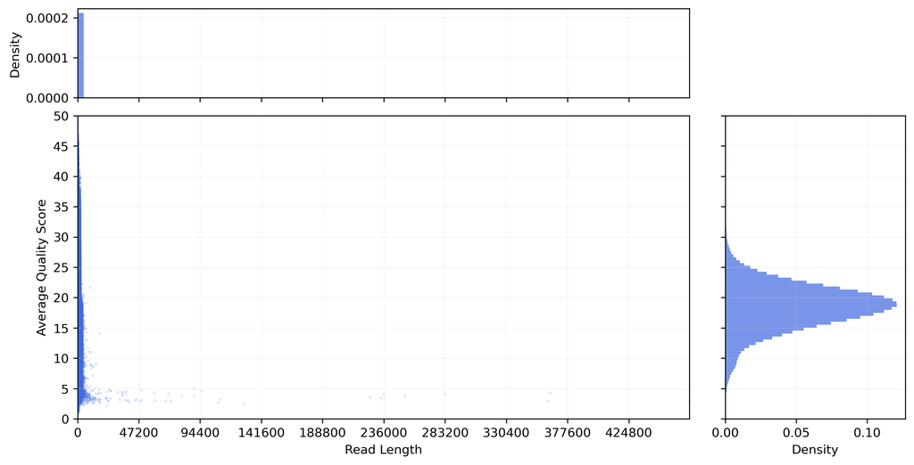

**Results indicate the best thresholds are…**

**Length Min**

1400

**Length Max**

1700

**QC Score**

15

### Proname Filter

Now you need to inspect the initial results to select options for the following filter parameters:

**`filtminlen`**

Reads with a length below this threshold will be discarded during quality filtering. [Option: integer]

**`filtmaxlen`**

Reads with a length above this threshold will be discarded during quality filtering. [Option: integer]

**`filtminqual`**

Reads with a quality score below this threshold will be discarded during quality filtering. [Option: integer]

```
# batch_scripts/proname_filter.sh

#!/bin/bash
#SBATCH --job-name=proname_filter
#SBATCH --partition=batch
#SBATCH --nodes=1
#SBATCH --ntasks=1
#SBATCH --cpus-per-task=8
#SBATCH --mem=32G
#SBATCH --time=02:00:00
#SBATCH --output=/work/richlab/aliciarich/read_processing/logs/proname_filter_%j.out
#SBATCH --error=/work/richlab/aliciarich/read_processing/logs/proname_filter_%j.err


#

module load apptainer

IMG_DIR=/work/richlab/aliciarich/read_processing/containers
IMG=$IMG_DIR/proname_v2.0.1-amd64.sif

IN_DIR=/work/richlab/aliciarich/read_processing/reads/demuxed_trimmed/samples
OUT_DIR=/work/richlab/aliciarich/read_processing/processed/loris/proname
mkdir -p "$OUT_DIR"

apptainer exec \
  --bind "$IN_DIR":"$IN_DIR" \
  --bind "$OUT_DIR":"$OUT_DIR" \
  --pwd  "$OUT_DIR" \
  "$IMG" \
  proname_filter \
      --inputpath "$IN_DIR" \
      --threads $SLURM_CPUS_PER_TASK \
      --datatype simplex \
      --filtminlen 1400 \
      --filtmaxlen 1700 \
      --filtminqual 15
```

#### After Running Script

Repeat the same file transfer and view your updated filtering results before proceeding.

**Updated Length vs. Quality Scatter Plot**

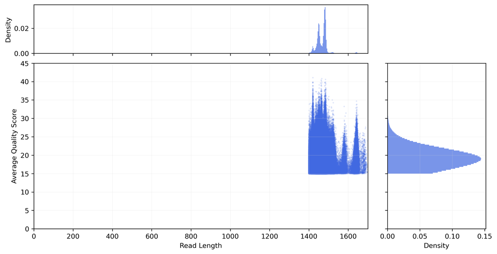

`LengthvsQualityScatterPlot_HQ_simplex.png`

### Proname Refine

Now you should consider your data quality and goals to select options for the following consensus parameters:

**`clusterid`**

The percentage of identity at which clustering should be performed. [Option: decimal between 0 and 1]

**`subsampledreads`**

Number of subsampled reads that will be aligned against the centroid sequence during polishing. [Default: 300]

**`chimeramethod`**

Specify the chimera detection method: “ref” (reference-based) or “denovo” (de novo detection). [Default: “ref”]

**`chimeradb`**

Path to the reference database to use for the chimera detection.

You may use the *rEGEN-B (rrn operons Extracted from GENomes of Bacteria)* database included in the docker image or provide another like *SILVA*.

**`medakamodel`**

This should be the dorado basecaller model that you used to generate these files.

```
# batch_scripts/proname_refine.sh

#!/bin/bash
#SBATCH --job-name=proname_refine
#SBATCH --partition=batch
#SBATCH --nodes=1
#SBATCH --ntasks=1
#SBATCH --cpus-per-task=8
#SBATCH --mem=32G
#SBATCH --time=03:00:00
#SBATCH --output=/work/richlab/aliciarich/read_processing/logs/proname_refine_%j.out
#SBATCH --error=/work/richlab/aliciarich/read_processing/logs/proname_refine_%j.err

#

IMG_DIR=/work/richlab/aliciarich/read_processing/containers
IMG=$IMG_DIR/proname_v2.0.1-amd64.sif

IN_DIR=/work/richlab/aliciarich/read_processing/reads/demuxed_trimmed/samples
OUT_DIR=/work/richlab/aliciarich/read_processing/processed/loris/proname
mkdir -p "$OUT_DIR"

apptainer exec \
  --bind "$IN_DIR":"$IN_DIR" \
  --bind "$OUT_DIR":"$OUT_DIR" \
  --pwd  "$OUT_DIR" \
  "$IMG" \
  proname_refine \
      --clusterid 0.9 \
      --inputpath "$IN_DIR" \
      --medakamodel dna_r10.4.1_e8.2_400bps_sup@v5.2.0 \
      --chimeradb /opt/db/rEGEN-B/rEGEN-B_sequences.fasta \
      --qiime2import yes \
      --clusterthreads $SLURM_CPUS_PER_TASK \
      --medakathreads $SLURM_CPUS_PER_TASK
```

**To watch log files from terminal:**

```
tail -f /work/richlab/aliciarich/read_processing/logs/proname_refine_10921629.out
tail -f /work/richlab/aliciarich/read_processing/logs/proname_refine_10921629.err
```

### Proname Taxonomy

```
# batch_scripts/proname_taxonomy.sh

#!/bin/bash
#SBATCH --job-name=proname_taxonomy
#SBATCH --partition=batch
#SBATCH --nodes=1
#SBATCH --ntasks=1
#SBATCH --cpus-per-task=8
#SBATCH --mem=32G
#SBATCH --time=03:00:00
#SBATCH --output=/work/richlab/aliciarich/read_processing/logs/proname_taxonomy_%j.out
#SBATCH --error=/work/richlab/aliciarich/read_processing/logs/proname_taxonomy_%j.err

#

IMG_DIR=/work/richlab/aliciarich/read_processing/containers
IMG=$IMG_DIR/proname_v2.0.1-amd64.sif

OUT_DIR=/work/richlab/aliciarich/read_processing/processed/loris/proname
mkdir -p "$OUT_DIR"

apptainer exec \
  --bind "$OUT_DIR":"$OUT_DIR" \
  --pwd "$OUT_DIR" \
  "$IMG" \
  proname_taxonomy \
      --threads $SLURM_CPUS_PER_TASK \
      --qseqs rep_seqs.qza \
      --qtable rep_table.qza \
      --db /opt/db/rEGEN-B/rEGEN-B_sequences.fasta \
      --reftax /opt/db/rEGEN-B/rEGEN-B_taxonomy.tsv \
      --metadata sample_metadata.tsv  \
      --assay hdz_all \
      --phyloseq yes
```

## Generate Phylogeny

```
# batch_scripts/qiime_phylo.sh

#!/bin/bash
#SBATCH --job-name=qiime_phylo
#SBATCH --partition=guest
#SBATCH --nodes=1
#SBATCH --ntasks=1
#SBATCH --cpus-per-task=8
#SBATCH --mem=32G
#SBATCH --time=03:00:00
#SBATCH --output=/work/richlab/aliciarich/read_processing/logs/qiime_phylo_%j.out
#SBATCH --error=/work/richlab/aliciarich/read_processing/logs/qiime_phylo_%j.err
#

IMG_DIR=/work/richlab/aliciarich/read_processing/containers
IMG=$IMG_DIR/proname_v2.0.1-amd64.sif

OUT_DIR=/work/richlab/aliciarich/read_processing/processed/loris/proname
mkdir -p "$OUT_DIR"

apptainer exec \
  --bind "$OUT_DIR":"$OUT_DIR" \
  --pwd "$OUT_DIR" \
  "$IMG" \
  qiime phylogeny align-to-tree-mafft-fasttree \
    --i-sequences ${pwd}/rep_seqs.qza \
    --o-alignment ${pwd}/aligned_rep_seqs.qza \
    --o-masked-alignment ${pwd}/masked_aligned_rep_seqs.qza \
    --o-tree ${pwd}/unrooted_tree.qza \
    --o-rooted-tree ${pwd}/rooted_tree.qza
```

## Assign Taxonomy using `wf-16s`

Now we will supplement `PRONAME`’s consensus-based approach with the ONT mainstream approach included in the EPI2ME Labs `wf-16s` pipeline. This pipeline assigns taxonomy to each read by using `minimap2` to align each read to a reference sequence on NCBI’s 16S database.

> Note that I am using the same length and quality thresholds selected during the `proname_filter` step of that pipeline. I am using the default values for all other quality control parameters. These will be noted in the report produced, but you can also see them and your other options for the pipeline on the [`wf-16s` README page.](https://github.com/epi2me-labs/wf-16s)

```
# batch_scripts/wf16s.sh

#!/bin/bash
#SBATCH --job-name=wf16s
#SBATCH --partition=guest,batch
#SBATCH --nodes=1
#SBATCH --ntasks=1
#SBATCH --cpus-per-task=16
#SBATCH --mem=350G
#SBATCH --time=03:00:00
#SBATCH --output=/work/richlab/aliciarich/read_processing/logs/wf16s_%j.out
#SBATCH --error=/work/richlab/aliciarich/read_processing/logs/wf16s_%j.err
#

module load nextflow

pwd=/work/richlab/aliciarich/read_processing
input=/work/richlab/aliciarich/read_processing/reads/demuxed_trimmed/samples
output=/work/richlab/aliciarich/read_processing/processed/loris/wf16s

mkdir -p $output

cd $pwd

nextflow run epi2me-labs/wf-16s \
    --fastq $input \
  --keep_bam \
  --minimap2_by_reference \
  --include_read_assignments \
  --igv \
  --out_dir $output \
  --min_len 1400 \
  --max_len 1700 \
  --min_read_qual 15 \
  --threads $SLURM_CPUS_PER_TASK \
  -profile singularity -resume
```

**To watch log files from terminal:**

```
tail -f /work/richlab/aliciarich/read_processing/logs/wf16s_10922583.out
tail -f /work/richlab/aliciarich/read_processing/logs/wf16s_10922583.err
```

### After Running Script

**What your `wf-16s` Output Should Look Like:**

[output not shown]

# Next Steps

Your 16s reads are now fully processed for analysis and visualization. Make sure you keep your `.fastq` and `.bam` files that you used here in at least one cloud-based repository and one local hard-drive with clear labels, as you will set them aside for the rest of your work but may need to return to them later (you will also be required to make these fully available for any publications). Now your working data will consist of taxonomic observations and phylogenetic patterns across samples, which are what you generated several versions of here.

You will switch over to the [`bioinformatics_stats`](https://rich-molecular-health-lab.github.io/bioinformatics_stats) repository next, so you should transfer the most important datasets from your processed directory into a working directory on that repository. You will begin with the [`metadata_setup`](https://rich-molecular-health-lab.github.io/tutorials/metadata_setup.html) script in the `bioinformatics_stats` repository so that you are ready to match your metadata to the sample identities and read counts you generated here. Then you will proceed to a [`microbiome_preprocess`](https://rich-molecular-health-lab.github.io/tutorials/microbiome_preprocess.html) script to proceed with *more* quality control steps for the taxonomic counts and phylogenetic trees you produced here.